# some practical pydata tips

### and Python for Astrophysics

Michael Gully-Santiago, PhD  
Postdoctoral Researcher  
Kavli Institute for Astronomy & Astrophysics  
at Peking University, Beijing, China

# Practical pydata tips

1. **Conda/anaconda is the easiest way to manage python dependencies.**
2. **Jupyter notebooks are great for interactive data analysis, reproducibility.**
3. **Jupyter notebooks shift-tab feature is the best way to explore APIs through docstrings and experimentation.**
4. **This presentation was made from a Jupyter Notebook, converted to reveal.js.**
5. **Pandas pd.read_csv() is probably the most useful thing for a data scientist.**
6. **HackerRank is a great way to learn Python and discover "coding accents"-- large variety of how people code the same thing.**
7. **Bokeh is a cool thing for making interactive D3 plots from Python.**
8. **Tensorflow has a Python API.**

### Conda/anaconda is the easiest way to manage python dependencies.

```python
! wget https://repo.continuum.io/miniconda/Miniconda3-latest-MacOSX-x86_64.sh
```

[output not shown]

```python
! ls -1 Miniconda*
```

```
Miniconda2-latest-MacOSX-x86_64.sh
Miniconda3-latest-MacOSX-x86_64.sh
```

```python
! conda update conda
```

```python
! conda install numpy scipy pandas matplotlib jupyter seaborn bokeh mkl
```

```
Using Anaconda Cloud api site https://api.anaconda.org
Fetching package metadata .........
Solving package specifications: ..........

Package plan for installation in environment //anaconda:

The following packages will be downloaded:

    package                    |            build
    ---------------------------|-----------------
    bokeh-0.12.1               |           py34_0         3.3 MB
    seaborn-0.7.1              |           py34_0         283 KB
    ------------------------------------------------------------
                                           Total:         3.5 MB

The following packages will be UPDATED:

    bokeh:   0.11.1-py34_0 --> 0.12.1-py34_0
    seaborn: 0.7.0-py34_0  --> 0.7.1-py34_0

Proceed ([y]/n)? ^C
Operation aborted.  Exiting.
```

```python
! conda list
```

[output not shown]

[output cut: 187 more lines]

[output not shown]

### Jupyter notebooks are great for interactive data analysis, reproducibility.

```
(-3, 0)
```

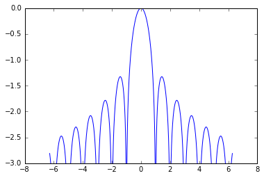

```python
import matplotlib.pyplot as plt
import numpy as np
%matplotlib inline
x = np.linspace(-2.0*np.pi, 2.0*np.pi, 10000)
y = np.sinc(x)**2
plt.plot(x, np.log10(y))
plt.ylim(-3, 0)
```

### Jupyter notebooks shift-tab feature is the best way to explore APIs through docstrings and experimentation.

```python
import pandas as pd
```

```python
pd.read_csv( #hit shift-tab and see what happens!
```

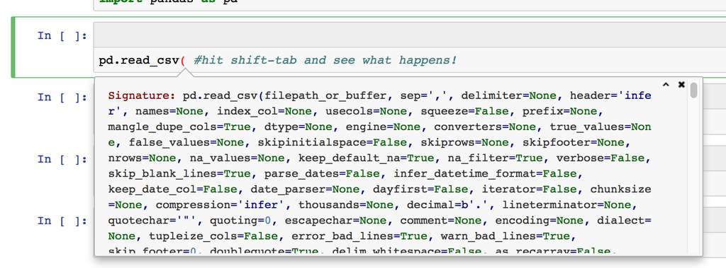

```python
Image('../figs/shift_tab_example.png')
```

### This presentation was made from a Jupyter Notebook, and converted to reveal.js.

```python
! jupyter-nbconvert BJpy_01-01_First_trial.ipynb --to slides --post serve
```

```
[NbConvertApp] Converting notebook BJpy_01-01_First_trial.ipynb to slides
[NbConvertApp] Writing 561235 bytes to BJpy_01-01_First_trial.slides.html
[NbConvertApp] Redirecting reveal.js requests to https://cdnjs.cloudflare.com/ajax/libs/reveal.js/3.1.0
Serving your slides at http://127.0.0.1:8000/BJpy_01-01_First_trial.slides.html
Use Control-C to stop this server
WARNING:tornado.access:404 GET /custom.css (127.0.0.1) 0.51ms
WARNING:tornado.access:404 GET /custom.css (127.0.0.1) 0.55ms
^C
Interrupted
```

### Pandas `pd.read_csv()` is probably the most useful thing for a data scientist.

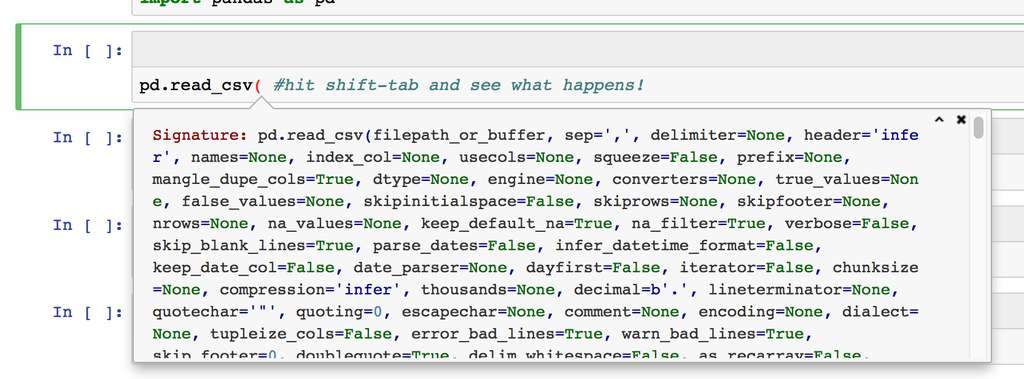

```python
Image(filename='../figs/shift_tab_example.png')
```

### HackerRank is a great way to learn Python and discover "coding accents"-- the variety of how people code the same problem in the same language (Python).

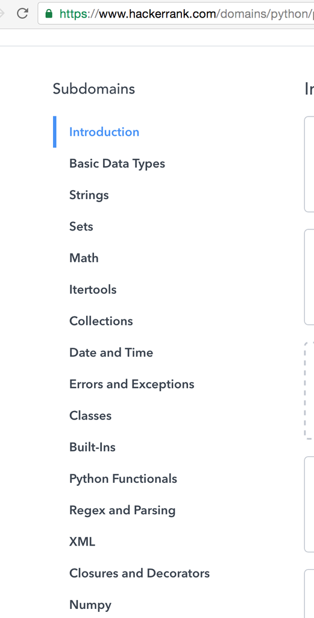

```python
Image('../figs/hackerrank_python.png', width=300)
```

> Find the Second Largest Number: https://www.hackerrank.com/challenges/find-second-maximum-number-in-a-list

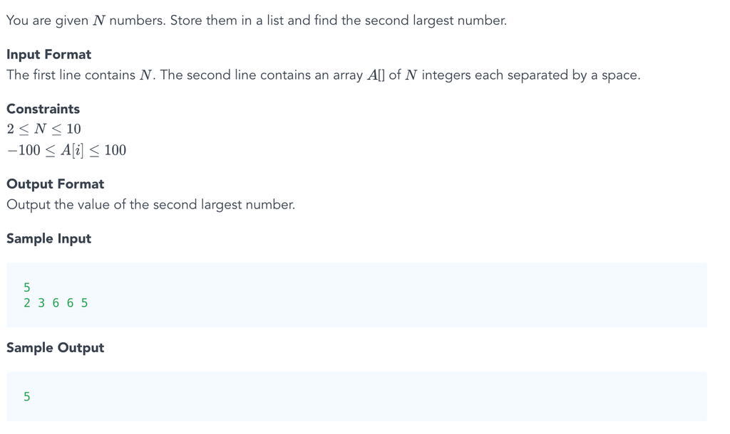

```python
Image('../figs/hackerrank_problem_setup.png')
```

```python
# Python 2!
n = int(raw_input())
uniq_vals = list(set(map(int, raw_input().split())))
uniq_vals.sort()
print uniq_vals[-2]
```

[output not shown]

```python
# Python 3
n = int(input())
uniq_vals = list(set(map(int, input().split())))
uniq_vals.sort()
print(uniq_vals[-2])
```

```
5
2 3 6 6 5
5
```

```python
# From user alexander_zhou
def findSM(l):
    f, s = l[0], l[0]
    for i in range(len(l)):
        if l[i] > f:
            s, f = f, l[i]
        elif l[i] < f:
            if f == s:
                s = l[i]
            elif l[i] > s:
                s = l[i]
    return s

n = int(input())
l = input().split()
for i in range(n):
    l[i] = int(l[i])

print(findSM(l))
```

```python
# From user richmond
import random
import sys
i = 1
for line in sys.stdin:
    if i == 1:
        if 2>int(line) and int(line)>100:
            break
    else:
        r = line
        s = []
        sss = r.split(' ')
        for ss in sss:
            s.append(int(ss))
        __s = -100
        for i in s:
            if i > __s:
                __s = i
        _s = -100
        for i in s:
            if i != __s:
                if i > _s:
                    _s = i

        print _s
        break
    i += 1
```

```python
# From user dragonfury
a = int(raw_input())

b = [int(x) for x in raw_input().split(' ')]

m=-101
for i in range(0,a):
    if m<b[i]:
        m=b[i]

for i in range(0,a):
    if b[i] == m:
      b[i]=-101

m=-101
for i in range(0,a):
    if m<b[i]:
        m=b[i]

print(m)
```

```python
x=input()
a=raw_input()
a=a.split(' ')
a=map(int,a)
a=set(a)
a=list(a)
a.sort()
print a[len(a)-2]
```

```python
# From user Matiel
N = int(input())
liste = input().split()
i = 0
for nombre in liste:
    liste[i] = int(nombre)
    i += 1

maximum = max(liste)
preMax = min(liste)
for nombre in liste:
    if (nombre < maximum and nombre > preMax):
        preMax = nombre

print(preMax)
```

```python
# from user Kabashka
import subprocess
import os
import sys

sizeOfData = int(sys.stdin.readline())
a = map(int,sys.stdin.readline().replace('\n','').split(' '))

lastMax = a[0]
max = a[0]

for i in a:
  if i > max:
    lastMax=max
    max = i
  elif i==max:
    continue
  elif i > lastMax:
    lastMax = i
  elif lastMax==max:
    lastMax = i

sys.stdout.write(str(lastMax))
```

```python
import numpy as np

from bokeh.plotting import figure, show, output_file
from bokeh.io import output_notebook
output_notebook()

N = 4000
x = np.random.random(size=N) * 100
y = np.random.random(size=N) * 100
radii = np.random.random(size=N) * 1.5
colors = [
    "#%02x%02x%02x" % (int(r), int(g), 150) for r, g in zip(50+2*x, 30+2*y)
]

TOOLS="crosshair,pan,wheel_zoom,box_zoom,undo,redo,reset,tap,save,box_select,poly_select,lasso_select"

p = figure(tools=TOOLS)

p.scatter(x, y, radius=radii,
          fill_color=colors, fill_alpha=0.6,
          line_color=None)

output_file("color_scatter.html", title="color_scatter.py example")

show(p)  # open a browser
```

Loading BokehJS ...

`<Bokeh Notebook handle for In[38]>`

### Tensorflow has a Python API.

### Fizz Buzz in Tensorflow http://joelgrus.com/2016/05/23/fizz-buzz-in-tensorflow/

> **interviewer:** OK, so are you familiar with "fizz buzz"?

> **me:** ...

> **interviewer:** Is that a yes or a no?

> **me:** It's more of a "I can't believe you're asking me that."

> **interviewer:** OK, so I need you to print the numbers from 1 to 100, except that if the number is divisible by 3 print "fizz", if it's divisible by 5 print "buzz", and if it's divisible by 15 print "fizzbuzz".

> **me:** I'm familiar with it.

> **interviewer:** Great, we find that candidates who can't get this right don't do well here.

> **me:** ...

> **interviewer:** Here's a marker and an eraser.

> **interviewer:** Do you need help getting started?

> **me:** No, no, I'm good. So let's start with some standard imports:

```python
import numpy as np
import tensorflow as tf
```

> **interviewer:** Um, you understand the problem is fizzbuzz, right?

> **me:** Do I ever. So, now let's talk models. I'm thinking a simple multi-layer-perceptron with one hidden layer.

> **interviewer:** OK, that's probably enough.

> **me:** That's enough setup, you're exactly right. Now we need to generate some training data. It would be cheating to use the numbers 1 to 100 in our training data, so let's train it on all the remaining numbers up to 1024:

```python
def fizz_buzz_encode(i):
    if   i % 15 == 0: return np.array([0, 0, 0, 1])
    elif i % 5  == 0: return np.array([0, 0, 1, 0])
    elif i % 3  == 0: return np.array([0, 1, 0, 0])
    else:             return np.array([1, 0, 0, 0])

def fizz_buzz(i, prediction):
    return [str(i), "fizz", "buzz", "fizzbuzz"][prediction]

def model(X, w_h, w_o):
    h = tf.nn.relu(tf.matmul(X, w_h))
    return tf.matmul(h, w_o)
```

[output not shown]